## Úkol 4.1

Nasimulujte z normálního normovaného rozdělení 70 (vzájemně nezávislých) hodnot pro každou z dvaceti níže uvažovaných proměnných. S využitím těchto dat pomocí regresního vztahu:

$$𝑦_𝑖 = 𝛽_1 𝑥_{1,i} + 𝛽_2 𝑥_{2,𝑖} + ... +
𝛽_{20} x_{20,i} + 𝑢_𝑖$$
nasimulujte hodnoty závislé proměnné $𝑦$, kde parametry $𝛽_1$ až $𝛽_{10} = 1$ a parametry $𝛽_{11}$ až $𝛽_{20} = 0,1$. Náhodná chyba $u_i$ je normálně rozdělená se střední hodnotou 0 a rozptylem 1. Takto připravená data od tohoto okamžiku považujte za daná.

Datový soubor rozdělte na 50 a 20 pozorování. Prvních 50 pozorování použijete pro trénování, zbylých 20 jako testovací množinu pro odhad střední čtvercové (predikční) chyby.

1. Naučte na daných datech model metodou gradient boosting. Jako slabé modely použijte jednoduchou lineární regresy s jednou vysvětlující proměnnou. Použijte míru rychlosti učení o celikosti 0,1. Využijte kvadratickou ztrátovou funkci.
2. Naučený model použijte pro získání předpovědí na testovací množině a určete velikost střední čtvercové chyby. Výsledky srovnejte s těmi, které jste získali v minulém úkolu pomocí hřebenové regresse a LASSO regrese

```r
library(gbm)
library(ipred)
library(rpart)
library(randomForest)
```

```r
data <- as.data.frame(matrix(nrow = 70, ncol = 21))
colnames(data) <- c("X1", "X2", "X3", "X4", "X5", "X6", "X7", "X8", "X9", "X10", "X11", "X12", "X13", "X14", "X15", "X16", "X17", "X18", "X19", "X20", "Y")

for(i in 1:20){
  data[,i] <- rnorm(70)
}

data$Y <- 10*data$X1 + 10*data$X2 + 10*data$X3 + 10*data$X4 + 10*data$X5 + 10*data$X6 + 10*data$X7 + 10*data$X8 + 10*data$X9 + 10*data$X10 + 0.1*data$X11 + 0.1*data$X12 + 0.1*data$X13 + 0.1*data$X14 + 0.1*data$X15 + 0.1*data$X16 + 0.1*data$X17 + 0.1*data$X18 + 0.1*data$X19 + 0.1*data$X20 + rnorm(1)
#data$Rozdeleni <- rep(1:5, 14)
```

```r
#Rozdělení dat na trénovací a testovací
data_train <- data[1:50,]
data_test <- data[51:70,]
```

### Gradient boosting

```r
gbm_model <- gbm(Y ~ X1, data = data_train, distribution = "gaussian", shrinkage = 0.1, n.trees = 5000)

new_data <- data.frame(X1 = data_test[,1])
predikce_gbm <- predict.gbm(gbm_model, newdata = new_data)

#-----

gbm_model2 <- gbm(Y ~ ., data = data_train, distribution = "gaussian", shrinkage = 0.1, n.trees = 5000)

predikce_gbm2 <- predict.gbm(gbm_model2, newdata = data_test[,-21])
```

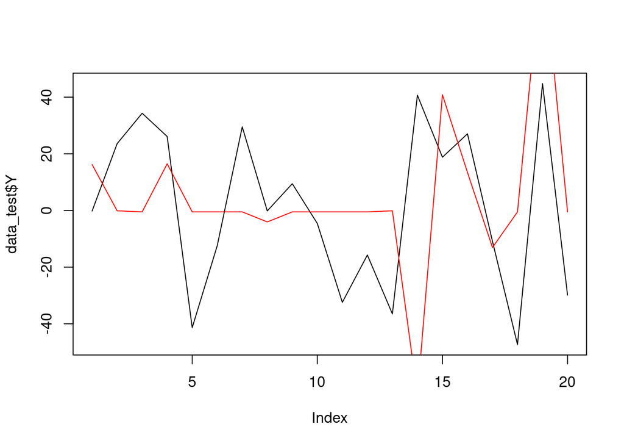

```r
rezidua <- predikce_gbm - data_test$Y
plot(data_test$Y, type = "l")
lines(predikce_gbm, col = "red")
```

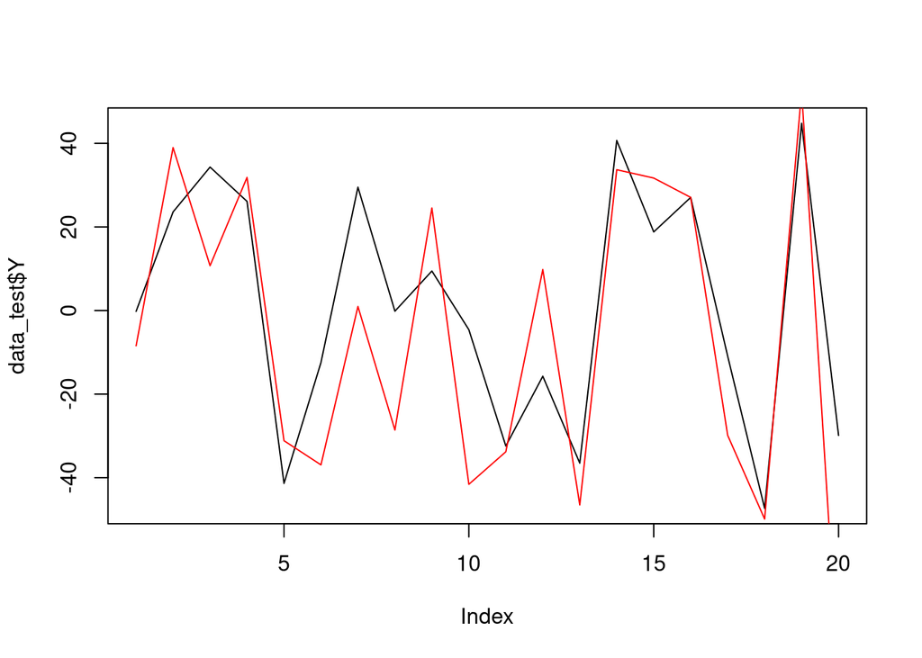

```r
rezidua2 <- predikce_gbm2 - data_test$Y
plot(data_test$Y, type = "l")
lines(predikce_gbm2, col = "red")
```

```r
c("MSE" = mean(rezidua^2), "MSE2" = mean(rezidua2^2))
```

```
##       MSE      MSE2
## 1233.7093  477.5843
```

## Úkol 4.2

Pokuste se zreplikovat cvičení na Bagging z přednášek, viz snímky 5-8 v prezentaci. Předpokládejte data:

| xi | 0.21 | 0.21 | 0.09 | 0.60 | 0.99 | 0.75 | 0.24 | 0.09 | 0.23 | 0.73 |
| --- | --- | --- | --- | --- | --- | --- | --- | --- | --- | --- |
| yi | 0.93 | 0.90 | 0.71 | -0.46 | -0.21 | -1.07 | 1.06 | 0.45 | 1.07 | -0.97 |

S využitím dat odhadněte regresní koeficienty polynomické regrese

$$𝑦_𝑖 = 𝛽_0+ 𝛽_1 𝑥_i + 𝛽_2 𝑥_𝑖^2 + ... +
𝛽_{7} x_i^7 + 𝑢_𝑖$$

V grafu zobrazte vyrovnané hodnoty i predikce pro jednotlivá x z intervalu (0,1). Posuďte, jak získané predikce dopadají z pohledu kompromisu mezi zkreslením a variabilitou. Následně se pokuste pomocí metody Bagging variabilitu snížit. V grafu ukažte finální predikce získané pomocí této metody a zhodnoťte, zda jsou blíže funkci, která bylake generování dat skutečně použita.

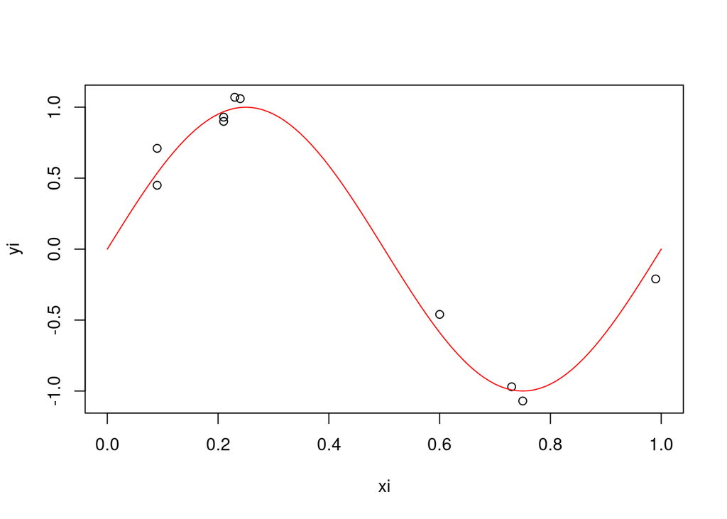

```r
fceZadani <- function(x){
  return(sin(2*pi*x))
}

plot(data_bagging[,c(1,2)], xlim = c(0,1))
curve(fceZadani(x), from = 0, to = 1, col = "red", add = T)
```

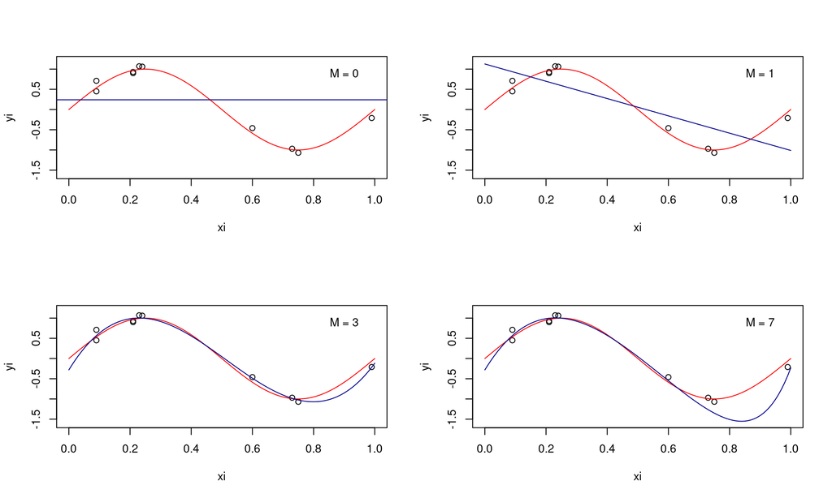

```r
model_M1 <- lm(yi ~ xi, data_bagging)
model_M3 <- lm(yi ~ xi + xi2 + xi3, data_bagging)
model_M7 <- lm(yi ~ xi + xi2 + xi3 + xi4 + xi5 + xi6 + xi7, data_bagging)

fceM3 <- function(x){
  hodnota <- sum(model_M3$coefficients * c(1, x, x^2, x^3))
  return(hodnota)
}

fceM7 <- function(x){
  hodnota <- sum(model_M3$coefficients * c(1, x, x^2, x^3, x^4, x^5, x^6, x^7))
  return(hodnota)
}

par(mfrow=c(2,2))

plot(data_bagging[,c(1,2)], xlim = c(0, 1), ylim = c(-1.6, 1.2))
curve(fceZadani(x), from = 0, to = 1, col = "red", add = T)
abline(h = mean(data_bagging$yi), col = "darkblue")
text(0.9, 0.9, "M = 0")

plot(data_bagging[,c(1,2)], xlim = c(0, 1), ylim = c(-1.6, 1.2))
curve(fceZadani(x), from = 0, to = 1, col = "red", add = T)
curve(model_M1$coefficients[1] + x * model_M1$coefficients[2], from = 0, to = 1, add = T, col = "darkblue")
text(0.9, 0.9, "M = 1")

plot(data_bagging[,c(1,2)], xlim = c(0, 1), ylim = c(-1.6, 1.2))
curve(fceZadani(x), from = 0, to = 1, col = "red", add = T)
curve(Vectorize(fceM3)(x), from = 0, to = 1, col = "darkblue", add = T)
text(0.9, 0.9, "M = 3")

plot(data_bagging[,c(1,2)], xlim = c(0, 1), ylim = c(-1.6, 1.2))
curve(fceZadani(x), from = 0, to = 1, col = "red", add = T)
curve(Vectorize(fceM7)(x), from = 0, to = 1, col = "darkblue", add = T)
text(0.9, 0.9, "M = 7")
```

### Bagging

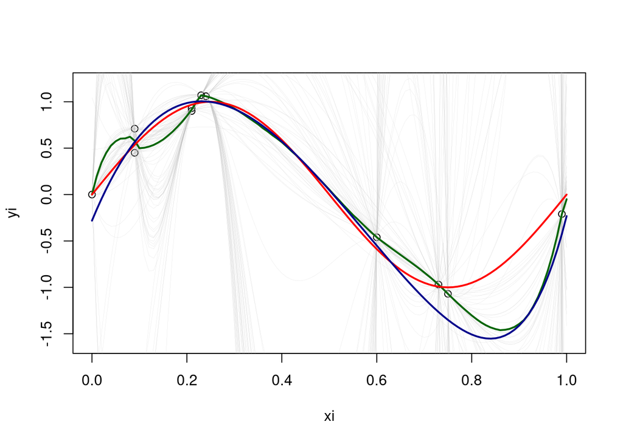

```r
data_bagging[11,] <- c(0,0)
ll <- matrix(NA, nrow = 3000, ncol = 101)

s <- seq(from = 0, to = 1, by = 0.01)
predikce_data <- data.frame(
  xi = s,
  xi2 = s^2,
  xi3 = s^3,
  xi4 = s^4,
  xi5 = s^5,
  xi6 = s^6,
  xi7 = s^7
)

for(i in 1:3000) {
  ss <- sort(sample(1:dim(data_bagging)[1], replace = T))

  d_b <- data_bagging[ss, ]
  m <- lm(yi ~ xi + xi2 + xi3 + xi4 + xi5 + xi6 + xi7, data = d_b)
  ll[i, ] <- predict(m, newdata = predikce_data)
}

plot(data_bagging[,c(1,2)], xlim = c(0, 1), ylim = c(-1.6, 1.2))
randI <- sort(sample(1:3000, 100))
for (i in randI) {
  lines(seq(from = 0, to = 1, by = 0.01), ll[i, ], col = "grey", lwd = 0.1)
}
lines(seq(from = 0, to = 1, by = 0.01), apply(ll, 2, median), col = "darkgreen", lwd = 2)
curve(fceZadani(x), from = 0, to = 1, col = "red", add = T, lwd = 2)
curve(Vectorize(fceM7)(x), from = 0, to = 1, col = "darkblue", add = T, lwd = 2)
```

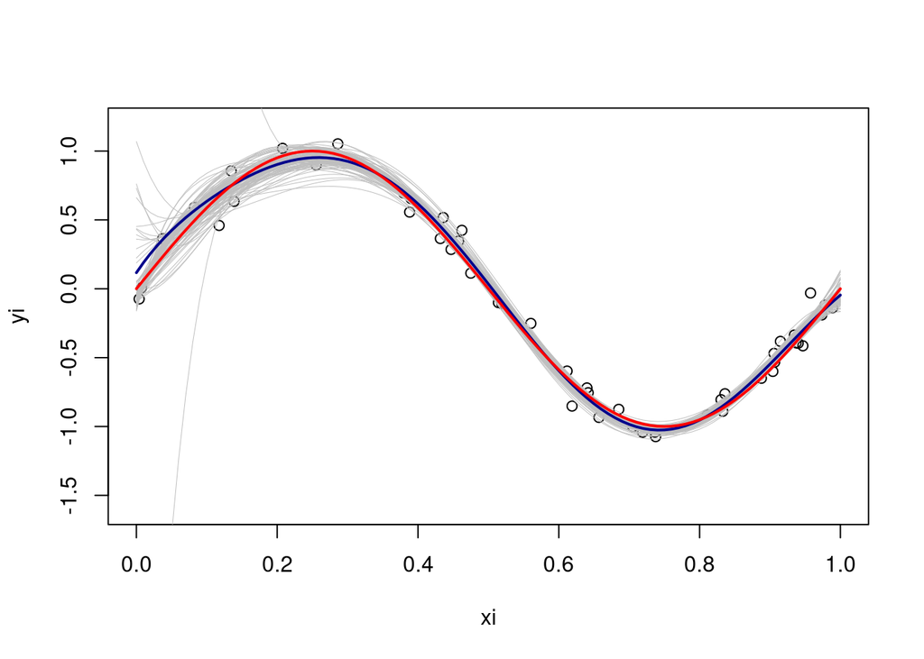

```r
data_bagging2 <- as.data.frame(matrix(nrow = 50, ncol = 0))
set.seed(42)
data_bagging2$xi <- runif(50)
data_bagging2$xi <- sort(data_bagging2$xi)
set.seed(52)
noise <- rnorm(50, sd = 0.1)
data_bagging2$yi <- fceZadani(data_bagging2$xi) + noise

data_bagging2$xi2 <- data_bagging2$xi^2
data_bagging2$xi3 <- data_bagging2$xi^3
data_bagging2$xi4 <- data_bagging2$xi^4
data_bagging2$xi5 <- data_bagging2$xi^5
data_bagging2$xi6 <- data_bagging2$xi^6
data_bagging2$xi7 <- data_bagging2$xi^7

ll2 <- matrix(NA, nrow = 100, ncol = 101)

for(i in 1:100) {
  ss2 <- sort(sample(1:dim(data_bagging2)[1], replace = T))

  d_b2 <- data_bagging2[ss2, ]
  m2 <- lm(yi ~ xi + xi2 + xi3 + xi4 + xi5 + xi6 + xi7, data = d_b2)
  ll2[i, ] <- predict(m2, newdata = predikce_data)
}

plot(data_bagging2[,c(1,2)], xlim = c(0, 1), ylim = c(-1.6, 1.2))
for (i in 1:100) {
  lines(seq(from = 0, to = 1, by = 0.01), ll2[i, ], col = "grey", lwd = 0.5)
}
lines(seq(from = 0, to = 1, by = 0.01), apply(ll2, 2, mean), col = "darkblue", lwd = 2)
curve(fceZadani(x), from = 0, to = 1, col = "red", add = T, lwd = 2)
```